# Comparing Percentages Between Groups

Three is a crowd…

P. Lombardo

## Loading packages, etc.

```r
library(tidyverse)
library(patchwork)
library(DescTools)
library(broom)
gss<-read.csv('data/gss.csv',header = T, stringsAsFactors = T)
bps_sample<-read.csv('data/bps_sample.csv', header = T,
                     stringsAsFactors = T)
```

In our previous lesson, we explored how to compare population means between two different groups using confidence intervals. In this lesson, we’ll do the same but focus on comparing populations by looking at percentages as a summary statistic.

There are just a few main differences:

1. Our testing assumptions are different, so we need to keep that in mind.
2. We will use `BinomDiffCI()` from the `DescTools` package to run our confidence intervals.
   - *Note*: like `BinomCI()`, this has us summarize our data in a `table()` first, and then plug in values. (There is a more streamlined way, but…)

## The `gss` data set

The `gss` data frame we loaded above gives information from the General Social Survey:

> “The General Social Survey is a high-quality survey which gathers data on American society and opinions, conducted since 1972.” - from the `infer` package documentation.

Let’s explore differences in the percentages of college degree holders among men and women, but let’s restrict our years to before 1990.

0. How must we prepare our data?

```r
# place code here.  # store your data frame as gss1
gss %>%
    filter(year < 1990) -> gss1
```

1. Are Men or Women the “Group 1” for this analysis?

```r
levels(gss1$sex)
```

```
## [1] "female" "male"
```

Group 1 is “female”

*What parameter are we estimating? (Make the order clear.)*

The population percentage of females with a college degree minus the popultion percentage of males with college degree.

2. Do we satisfy the assumptions of this test?
   - Here we will check the “10-yes-10-no” condition *in both groups*!

```r
#place code here
gss1 %>%
    select(sex, college) %>%
    table() %>% addmargins()
```

```
##         college
## sex      degree no degree Sum
##   female     21        56  77
##   male       21        78  99
##   Sum        42       134 176
```

Yes we satisfy the criterion for a CLT-based confidence interval; there are at least 10 men with college degree, and 10 without; there are at least 10 women with a college degree, and ten without.

3. Run the confidence interval using `BinomDiffCI()` with the “wald” method.

```r
# Use BinomDiffCI() fill in by group
BinomDiffCI(x1 = 21, n1 = 77,
            x2 = 21, n2 = 99,
            conf.level = .96)
```

```
##             est      lwr.ci    upr.ci
## [1,] 0.06060606 -0.07291807 0.1942365
```

(For fun, try some of the other methods!)

4. Interpret this confidence interval. What does it mean?
- Which group was “Group 1”? How does that affect our interpretation?

We can be 96% confident that the population percentage of females with college degree minus the population percentage of males with a college degree falls between -0.073 and 0.194.

- Since this interval contains zero, it remains possible that the percentage of college degree holders is equal among men and women at the population level.
- There is no evidence of a difference between these groups as measured by percentage of degree holders.

## Return to Police Stops

This is a “wilder” data set, so we have to do a little more preparation to get some of our code to work. Below, we’ll introduce some modifications we may need from time to time, including:

- `droplevels()`, which is sometimes necessary after a `filter()` command.

Let’s work our way through an example.

### Are Females more Likely to be pulled over during the day?

0. Create a 100%-stacked bar plot to compare Time of Day percentages between Men and Women.

*Show Work Below:*

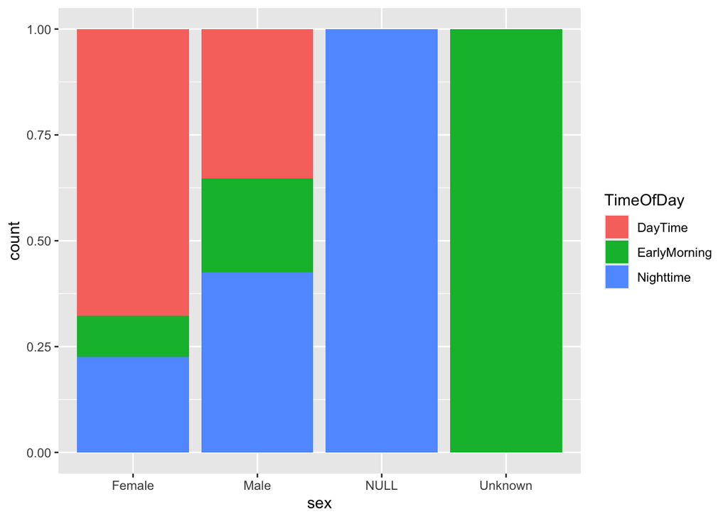

```r
#place code here.
ggplot(data = bps_sample,
       aes(x = sex, fill = TimeOfDay))+
    geom_bar(position = "fill")
```

There are too many categories, so as a research I want to make the following modifications:

- Look only at observations that were definitively categorized as Male and Female.
- Let’s combine the levels “EarlyMorning” and “Nighttime” into a single level, making that variable a binary one.

Prepare the data:

```r
# Place code here.
bps_sample %>%
# Filter to include only female/male, then droplevels
    filter(sex %in% c("Male","Female") ) %>%
    droplevels() %>%
# use mutate to create new variable is_day with only two levels.
    mutate(
        is_day = ifelse(TimeOfDay=="DayTime", "yes", "no")
    ) %>%
# Select the two variables we need.
    select(sex, is_day) -> bps1
```

1. Is Male or Female the “Group 1” for this analysis?

```r
levels(bps1$sex)
```

```
## [1] "Female" "Male"
```

Females are the group 1.

*What parameter are we estimating? (Make the order clear.)*

The pop. percentage of females stopped during the day minus the pop. percentage of males stopped during the day.

2. Do we satisfy the assumptions of this test?
   - Here we will check the “10-yes-10-no” condition *in both groups*!

```r
#place code here
bps1 %>% select(sex, is_day) %>%
    table() %>% addmargins()
```

```
##         is_day
## sex       no yes Sum
##   Female  10  21  31
##   Male   108  59 167
##   Sum    118  80 198
```

Yes, there are ten in each of the 4 possible categories based on sex and `is_day`.

3. Run the confidence interval using `BinomDiffCI()` with the “wald” method.

```r
# Use BinomDiffCI() fill in by group
BinomDiffCI(21, 31,
            59,167)
```

```
##            est    lwr.ci    upr.ci
## [1,] 0.3241259 0.1353608 0.4879134
```

4. Write a clear conclusion:

The difference in the percentage of daytime stops between males and females (with females as group 1) falls between 13.5% and 48.8%, with 95% confidence.

- This confidence interval does not contain zero and is positive, so we have evidence that the percentage of daytime stops for females **is larger** than the percentage for males (on the small end, by about 13.5%, but up to a difference of 48.8%!).

**Important additions:**

- If we `filter()` out certain levels of a categorical variable, it might be agood ideas to droplevels() when preparing your data frame.
- To combine levels together, we use `mutate()` to create a new variable.

*We will save this last example for after break to warm up!*

```r
bps_sample
```

| Date | Season | TimeOfDay | sex | race | age | AgeGrp | ethnicity | Frisk_Searched |
| --- | --- | --- | --- | --- | --- | --- | --- | --- |
| 10/27/19 | Fall | EarlyMorning | Male | Black | 22 | Adult | Not of Hispanic Origin | No |
| 12/14/19 | Winter | Nighttime | Male | Black | 26 | Adult | Not of Hispanic Origin | Yes |
| 11/19/19 | Fall | DayTime | Male | White | 39 | Adult | Not of Hispanic Origin | Yes |
| 10/24/19 | Fall | Nighttime | Male | Black | 20 | Adult | Hispanic Origin | No |
| 9/30/19 | Fall | DayTime | Female | Black | 54 | Adult | Not of Hispanic Origin | No |
| 10/4/19 | Fall | DayTime | Female | Black | 34 | Adult | Not of Hispanic Origin | No |
| 10/4/19 | Fall | Nighttime | Male | Black | 36 | Adult | Not of Hispanic Origin | No |
| 12/27/19 | Winter | EarlyMorning | Male | Black | 57 | Senior | Not of Hispanic Origin | Yes |
| 12/13/19 | Winter | EarlyMorning | Male | Black | 31 | Adult | Not of Hispanic Origin | Yes |
| 12/9/19 | Winter | DayTime | Female | Black | 29 | Adult | Not of Hispanic Origin | No |

[output cut: 190 more lines]

### One More Example:

Does Age Group have an association with whether one gets Frisked/Searched?

0. Create a 100%-stacked bar plot to compare and explore these variables.

*Show Work Below:*

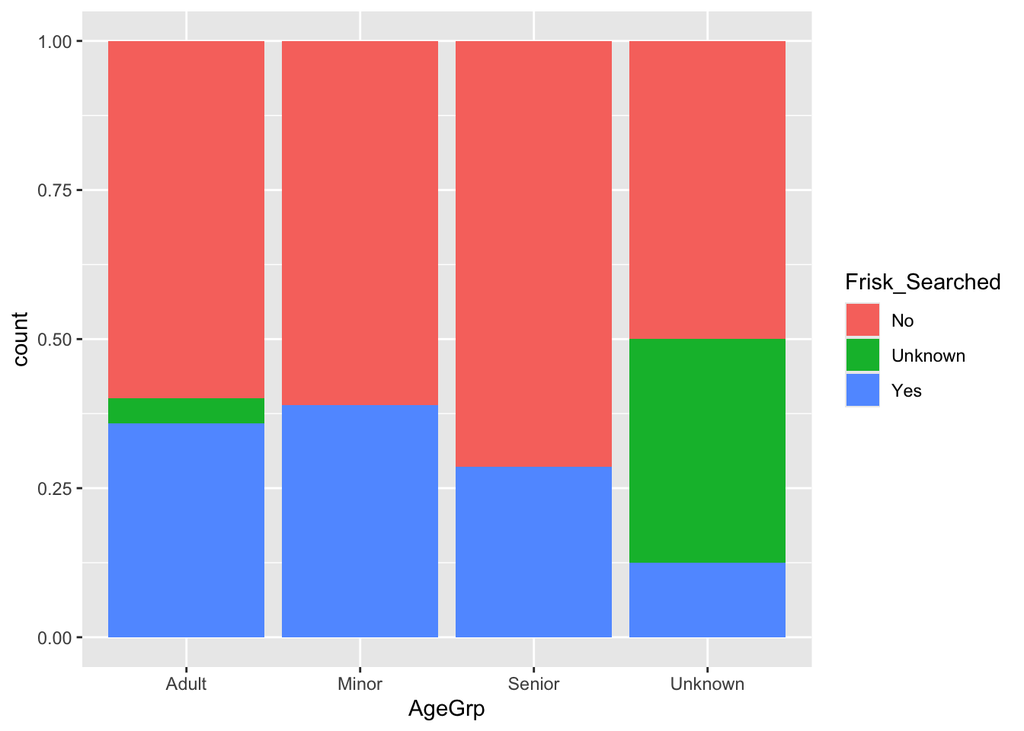

```r
#place code here.
ggplot(data = bps_sample,
       aes(x = AgeGrp, fill = Frisk_Searched))+
    geom_bar(position = "fill")
```

Summary table:

```r
bps_sample %>%
    select(AgeGrp, Frisk_Searched) %>%
    table() %>% # to compare rates
    prop.table(margin = 1)
```

```
##          Frisk_Searched
## AgeGrp            No    Unknown        Yes
##   Adult   0.59880240 0.04191617 0.35928144
##   Minor   0.61111111 0.00000000 0.38888889
##   Senior  0.71428571 0.00000000 0.28571429
##   Unknown 0.50000000 0.37500000 0.12500000
```

(*Note:* looking at row percentages (frisk rates by group) does mask the very low sample sizes in the non-adult categories.)

Thoughts:

- Let’s combine “Seniors” and “Adults” into one category of “Adult”.
- Let’s drop rows where either Age group or Frisk is “Unknown”

Prepare the data:

```r
# Place code here.
bps_sample %>% # let's first drop "Unknown"s
    filter(AgeGrp != "Unknown",
           Frisk_Searched != "Unknown") %>%
    droplevels() %>% # introduce a new variable
    # where we combine adult and senior
    mutate(
        is_minor = ifelse(AgeGrp == "Minor", "minor","other")
    ) %>%
    select(is_minor, Frisk_Searched) -> bps2
```

1. Is Minor or Adult the “Group 1” for this analysis?

*We get to choose when it’s a categorical response variable.* We choose to use “minor” as group 1.

*What parameter are we estimating? (Make the order clear.)*

> We are estimating the population frisk rate for minors minus the pop. frisk rate for adults.
2. Do we satisfy the assumptions of this test?
   - Here we will check the “10-yes-10-no” condition *in both groups*!

```r
#place code here
bps2 %>%
    select(is_minor, Frisk_Searched) %>%
    table() %>% addmargins()
```

```
##         Frisk_Searched
## is_minor  No Yes Sum
##    minor  11   7  18
##    other 105  62 167
##    Sum   116  69 185
```

**Oh no!** We do not satisfy the 10-yes-10-no condition for the “minor” group! We need a tweak.

3. Run the confidence interval using `BinomDiffCI()` with the “scorecc” method.

```r
# Table first
bps2 %>%
    select(is_minor, Frisk_Searched) %>%
    table() %>% addmargins()
```

```
##         Frisk_Searched
## is_minor  No Yes Sum
##    minor  11   7  18
##    other 105  62 167
##    Sum   116  69 185
```

```r
# Use BinomDiffCI() fill in by group
BinomDiffCI(x1 = 7, n1 = 18,   # minor goes first!
            x2 = 62, n2 = 167,
            method = "scorecc",
            conf.level = .92)
```

```
##            est     lwr.ci    upr.ci
## [1,] 0.0176314 -0.1867244 0.2551629
```

4. Write a clear conclusion:

Not so great, but technically correct: *We can be 92% confident that the frisk rate for minors minus the frisk rate for adults **at the population level** falls between -18.7% and 25.5%.*

Much better, clearer: *Because the confidence interval for a difference in percents contains zero, it remains possible that the population frisk rates are the same for minors and adults.*

5. Visualize again!

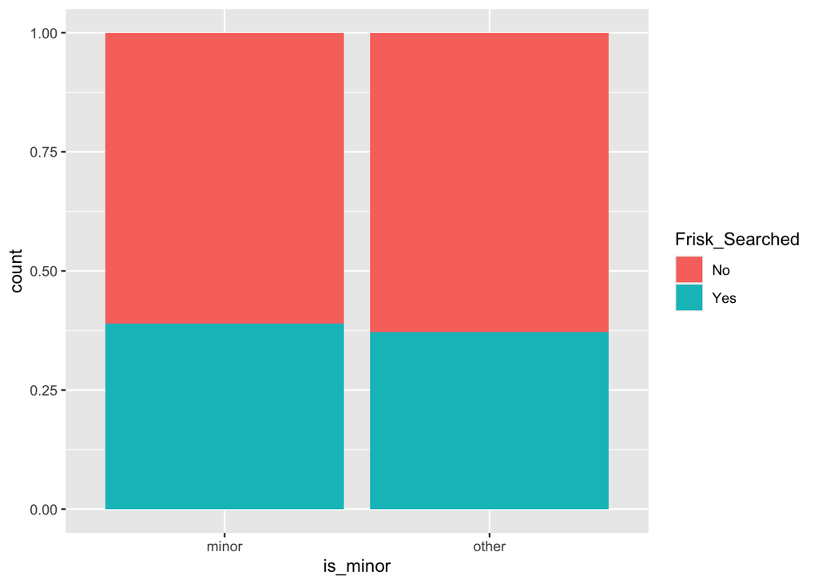

```r
# Place code for a plot here.
ggplot(data = bps2,
       aes(x = is_minor, fill = Frisk_Searched))+
    geom_bar(position="fill")
```